# Predicting ICU length of stay among patients with alcohol-associated liver disease

```r
## --- all will be dropped, except for ABPm, PTT, AST & ALT (sensitive indicators of liver-cell injury), and TBil which will be imputed after screening for outliers and inconsistent data
## --- Na, K, and Glucose levels are present in the serum labs, LFTs can replace DirectBil and Alb
## --- Unfortunately pO2 and pCO2 from abgas (maybe better to remove anyways, as they could be intubated and ambu-bagging as they enter the ICU), iCa, Lactate, Cortisol, Ammonia, CRP will have to be removed under the premise they are not routine labs taken for ALD patients in the ICU in this setting

## Remove all variables with over 10% of missingness (keeping only ABPm, PTT, AST, ALT, and TBil) and Remove all non-relevant variables from the dataset
aldNonLT_icu<-aldNonLT_icu|>
  select(-value_Glucose_poct, -value_pO2_abga, -value_pCO2_abga, -value_iCa, -value_Lactate, -value_Alb, -value_Na_blood, -value_K_blood, -value_Glucose_blood, -value_DirectBil, -value_Cortisol, -value_Ammonia, -value_CRP)|>
  select(-starts_with("valueuom"))
```

Reviewing, refining, and creating categorical variables

```r
tabyl(aldNonLT_icu$gender)
```

```
 aldNonLT_icu$gender    n   percent
                   F 1427 0.2933196
                   M 3438 0.7066804
```

```r
aldNonLT_icu$gender <- factor(aldNonLT_icu$gender, levels = c("F", "M"), labels = c("Female", "Male"))

tabyl(aldNonLT_icu$race)
```

```
                         aldNonLT_icu$race    n      percent
             AMERICAN INDIAN/ALASKA NATIVE   17 0.0034943474
                                     ASIAN   16 0.0032887975
                      ASIAN - ASIAN INDIAN   14 0.0028776978
                           ASIAN - CHINESE   14 0.0028776978
                  ASIAN - SOUTH EAST ASIAN    4 0.0008221994
                             BLACK/AFRICAN   18 0.0036998972
                    BLACK/AFRICAN AMERICAN  422 0.0867420349
                        BLACK/CAPE VERDEAN   35 0.0071942446
                    BLACK/CARIBBEAN ISLAND    9 0.0018499486
                        HISPANIC OR LATINO   69 0.0141829394
        HISPANIC/LATINO - CENTRAL AMERICAN   12 0.0024665982
               HISPANIC/LATINO - COLUMBIAN   15 0.0030832477
                   HISPANIC/LATINO - CUBAN    3 0.0006166495
               HISPANIC/LATINO - DOMINICAN   31 0.0063720452
              HISPANIC/LATINO - GUATEMALAN   42 0.0086330935
                HISPANIC/LATINO - HONDURAN   14 0.0028776978
                 HISPANIC/LATINO - MEXICAN   11 0.0022610483
            HISPANIC/LATINO - PUERTO RICAN   82 0.0168550874
              HISPANIC/LATINO - SALVADORAN   12 0.0024665982
                   MULTIPLE RACE/ETHNICITY    3 0.0006166495
 NATIVE HAWAIIAN OR OTHER PACIFIC ISLANDER    8 0.0016443988
                                     OTHER  101 0.0207605344
                PATIENT DECLINED TO ANSWER   21 0.0043165468
                                PORTUGUESE   51 0.0104830421
                            SOUTH AMERICAN    1 0.0002055498
                          UNABLE TO OBTAIN   81 0.0166495375
                                   UNKNOWN  417 0.0857142857
                                     WHITE 3227 0.6633093525
                         WHITE - BRAZILIAN    3 0.0006166495
                  WHITE - EASTERN EUROPEAN    6 0.0012332991
                    WHITE - OTHER EUROPEAN   92 0.0189105858
                           WHITE - RUSSIAN   14 0.0028776978
```

```r
aldNonLT_icu<-aldNonLT_icu|> ## new categories: White / Black / Hispanic.Latinx / Asian / Other / NA
  mutate(race=case_when(str_starts(race, "WHITE")~"White", str_starts(race, "BLACK")~"Black", str_starts(race, "HISPANIC")~"Hispanic.Latinx", str_starts(race, "ASIAN")~"Asian", race %in% c("AMERICAN INDIAN/ALASKA NATIVE", "MULTIPLE RACE/ETHNICITY", "NATIVE HAWAIIAN OR OTHER PACIFIC ISLANDER", "PORTUGUESE", "SOUTH AMERICAN", "OTHER")~"Other", race %in% c("PATIENT DECLINED TO ANSWER", "UNABLE TO OBTAIN", "UNKNOWN")~NA_character_))|>
  mutate(race=factor(race))

tabyl(aldNonLT_icu$language)
```

```
 aldNonLT_icu$language    n      percent valid_percent
               Amharic    1 0.0002055498  0.0002063983
               Chinese   14 0.0028776978  0.0028895769
               English 4553 0.9358684481  0.9397316821
                French    2 0.0004110997  0.0004127967
               Haitian    1 0.0002055498  0.0002063983
                 Hindi    6 0.0012332991  0.0012383901
          Kabuverdianu   37 0.0076053443  0.0076367389
                 Khmer    1 0.0002055498  0.0002063983
                 Other    8 0.0016443988  0.0016511868
                Polish    1 0.0002055498  0.0002063983
            Portuguese   31 0.0063720452  0.0063983488
               Russian   11 0.0022610483  0.0022703818
               Spanish  174 0.0357656732  0.0359133127
                  Thai    1 0.0002055498  0.0002063983
            Vietnamese    4 0.0008221994  0.0008255934
                  <NA>   20 0.0041109969            NA
```

```r
aldNonLT_icu<-aldNonLT_icu|> ## new categories: English / nonEnglish
  mutate(language = case_match(language, "English" ~ "English", .default = "nonEnglish", NA~NA_character_))|>
  mutate(language=factor(language))

tabyl(aldNonLT_icu$marital_status)
```

```
 aldNonLT_icu$marital_status    n    percent valid_percent
                    DIVORCED  565 0.11613566    0.12785698
                     MARRIED 1501 0.30853032    0.33966961
                      SINGLE 2154 0.44275437    0.48744060
                     WIDOWED  199 0.04090442    0.04503281
                        <NA>  446 0.09167523            NA
```

```r
aldNonLT_icu$marital_status <- factor(aldNonLT_icu$marital_status, levels=c("DIVORCED", "MARRIED", "SINGLE", "WIDOWED"), labels=c("Divorced", "Married", "Single", "Widowed"))

tabyl(aldNonLT_icu$insurance)
```

```
 aldNonLT_icu$insurance    n    percent valid_percent
               Medicaid 1676 0.34450154    0.35165757
               Medicare 1542 0.31695786    0.32354175
                  Other  227 0.04665982    0.04762904
                Private 1321 0.27153135    0.27717163
                   <NA>   99 0.02034943            NA
```

```r
aldNonLT_icu$insurance <- factor(aldNonLT_icu$insurance, levels=c("Medicaid","Medicare","Other","Private"), labels=c("Medicaid","Medicare","Other","Private"))

tabyl(aldNonLT_icu$admission_type)
```

```
 aldNonLT_icu$admission_type    n      percent
                DIRECT EMER.  107 0.0219938335
          DIRECT OBSERVATION    4 0.0008221994
                    ELECTIVE   33 0.0067831449
              EU OBSERVATION   11 0.0022610483
                    EW EMER. 2830 0.5817060637
           OBSERVATION ADMIT  836 0.1718396711
 SURGICAL SAME DAY ADMISSION  120 0.0246659815
                      URGENT  924 0.1899280576
```

```r
aldNonLT_icu<-aldNonLT_icu|> # new categories: Urgent / Elective
  mutate(admission_type=case_when(admission_type %in% c("DIRECT EMER.","DIRECT OBSERVATION","EU OBSERVATION", "EW EMER.", "OBSERVATION ADMIT", "URGENT")~"Urgent", admission_type %in% c("SURGICAL SAME DAY ADMISSION", "ELECTIVE")~"Elective"))|>
  mutate(admission_type=factor(admission_type))

aldNonLT_icu$EDvisit <- factor(aldNonLT_icu$EDvisit, levels = c("Yes", "No"))

aldNonLT_icu$los_icu4 <- factor(aldNonLT_icu$los_icu4, levels = c("≧ 4days in ICU", "< 4days in ICU"))
```

Imputing missing data

```r
## ABPm imputation using NIBPm, remove NIBPm from dataset as it is no longer needed
aldNonLT_icu<-aldNonLT_icu|>
  mutate(value_ABPm=ifelse(is.na(value_ABPm), aldNonLT_icu$value_NIBPm, value_ABPm))|>
  select(-value_NIBPm)
```

```r
## All continuous variables with missing data will be imputed using mean/median values (because all variables present a certain degree of skeweness) & using sapply
skewed_vitalNlabs<-c("los", "EDlos", "value_RR", "value_SpO2", "value_WBC", "value_PLT", "value_PTT", "value_INR", "value_Cr", "value_BUN", "value_AST", "value_ALT", "value_TBil")
normalized_vitalNlabs<-c("age", "value_HR", "value_ABPm", "value_Hgb", "value_Na_serum", "value_K_serum", "value_HCO3_serum", "value_Glucose_serum")
aldNonLT_icu<-aldNonLT_icu|>
  mutate(across(all_of(normalized_vitalNlabs), ~ ifelse(is.na(.), mean(., na.rm = TRUE), .))) |>
  mutate(across(all_of(skewed_vitalNlabs), ~ ifelse(is.na(.), median(., na.rm = TRUE), .)))
```

```r
## All categorical variables with missing data will be imputed using a random forest algorithm
set.seed(1111)

aldNonLT_icu <- aldNonLT_icu %>%
  select(-first_careunit, -last_careunit, -admission_location, -intime, -outtime, -admittime, -dischtime) # removing character and time format variables because missForest has trouble handling these formats. I plan to add them if needed in subsequent analyses.
aldNonLT_icu <- as.data.frame(aldNonLT_icu) # missForest doesn't work with tibbles. it needs to be a dataframe
aldNonLT_icu.imputed <- missForest(aldNonLT_icu, verbose=TRUE)$ximp
```

```
  missForest iteration 1 in progress...done!
    estimated error(s): 0 0.1179328
    difference(s): 0 0.005161585
    time: 4.32 seconds

  missForest iteration 2 in progress...done!
    estimated error(s): 0 0.114764
    difference(s): 0 0.001370332
    time: 4.08 seconds

  missForest iteration 3 in progress...done!
    estimated error(s): 0 0.1158856
    difference(s): 0 0.0009820715
    time: 3.97 seconds

  missForest iteration 4 in progress...done!
    estimated error(s): 0 0.1158426
    difference(s): 0 0.0009592326
    time: 4.03 seconds

  missForest iteration 5 in progress...done!
    estimated error(s): 0 0.1156554
    difference(s): 0 0.001233299
    time: 4.24 seconds
```

3. **Analyzing the data**

We will remove deaths in the ICU, as the length of ICU stay does not reflect their recovery outcomes.

```r
tabyl(aldNonLT_icu.imputed$ICUdeath) # n=630 (12.9%)
```

```
 aldNonLT_icu.imputed$ICUdeath    n   percent
                            No 4235 0.8705036
                           Yes  630 0.1294964
```

```r
aldNonLT_icu.survive<-aldNonLT_icu.imputed|>
  filter(ICUdeath=="No")
```

Descriptive analyses: What does my sample look like?

```r
label(aldNonLT_icu.survive$gender) <- "Gender"
label(aldNonLT_icu.survive$race) <- "Race"
label(aldNonLT_icu.survive$language) <- "Language"
label(aldNonLT_icu.survive$insurance) <- "Insurance"
label(aldNonLT_icu.survive$marital_status) <- "Marital Status"
label(aldNonLT_icu.survive$admission_type) <- "Admission Type"
label(aldNonLT_icu.survive$EDvisit) <- "ED Visit"
label(aldNonLT_icu.survive$age) <- "Age (years)"

cat("Demographic characteristics by ICU stay duration")
```

```
Demographic characteristics by ICU stay duration
```

```r
table1(~ age + gender + race + language + insurance + marital_status + admission_type + EDvisit | los_icu4,
       data = aldNonLT_icu.survive, rowlabelhead="Demographics")
```

| Demographics | ≧ 4days in ICU (N=1056) | < 4days in ICU (N=3179) | Overall (N=4235) |
| --- | --- | --- | --- |
| Age (years) |  |  |  |
| Mean (SD) | 55.5 (12.2) | 55.0 (12.1) | 55.1 (12.1) |
| Median [Min, Max] | 56.0 [19.0, 91.0] | 56.0 [20.0, 94.0] | 56.0 [19.0, 94.0] |
| Gender |  |  |  |
| Female | 325 (30.8%) | 887 (27.9%) | 1212 (28.6%) |
| Male | 731 (69.2%) | 2292 (72.1%) | 3023 (71.4%) |
| Race |  |  |  |
| Asian | 13 (1.2%) | 29 (0.9%) | 42 (1.0%) |
| Black | 89 (8.4%) | 351 (11.0%) | 440 (10.4%) |
| Hispanic.Latinx | 50 (4.7%) | 239 (7.5%) | 289 (6.8%) |
| Other | 46 (4.4%) | 108 (3.4%) | 154 (3.6%) |
| White | 858 (81.3%) | 2452 (77.1%) | 3310 (78.2%) |
| Language |  |  |  |
| English | 991 (93.8%) | 2988 (94.0%) | 3979 (94.0%) |
| nonEnglish | 65 (6.2%) | 191 (6.0%) | 256 (6.0%) |
| Insurance |  |  |  |
| Medicaid | 342 (32.4%) | 1192 (37.5%) | 1534 (36.2%) |
| Medicare | 335 (31.7%) | 1004 (31.6%) | 1339 (31.6%) |
| Other | 51 (4.8%) | 151 (4.8%) | 202 (4.8%) |
| Private | 328 (31.1%) | 832 (26.2%) | 1160 (27.4%) |
| Marital Status |  |  |  |
| Divorced | 108 (10.2%) | 404 (12.7%) | 512 (12.1%) |
| Married | 358 (33.9%) | 1056 (33.2%) | 1414 (33.4%) |
| Single | 536 (50.8%) | 1602 (50.4%) | 2138 (50.5%) |
| Widowed | 54 (5.1%) | 117 (3.7%) | 171 (4.0%) |
| Admission Type |  |  |  |
| Elective | 34 (3.2%) | 114 (3.6%) | 148 (3.5%) |
| Urgent | 1022 (96.8%) | 3065 (96.4%) | 4087 (96.5%) |
| ED Visit |  |  |  |
| Yes | 731 (69.2%) | 2568 (80.8%) | 3299 (77.9%) |
| No | 325 (30.8%) | 611 (19.2%) | 936 (22.1%) |

```r
#doesn't seem to be a difference based on the table (maybe a little difference in the ED visit?). Let's try visualizing
```

Visualizations

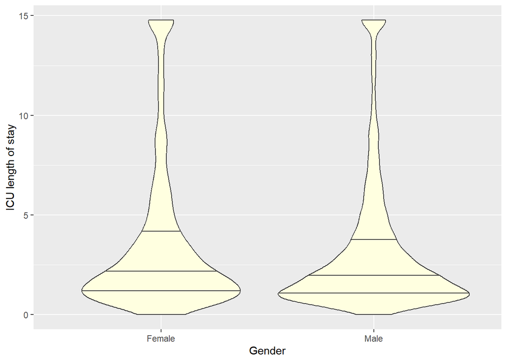

```r
losNgender<- ggplot(aldNonLT_icu.survive, aes(gender, los))+
  geom_violin(fill="lightyellow", draw_quantiles = c(0.25, 0.5, 0.75))+
  labs(x="Gender", y="ICU length of stay")

losNrace<-ggplot(aldNonLT_icu.survive, aes(race, los))+
  geom_violin(fill="lightyellow", draw_quantiles = c(0.25, 0.5, 0.75))+
  labs(x="Race", y="ICU length of stay")

losNlanguage<-ggplot(aldNonLT_icu.survive, aes(language, los))+
  geom_violin(fill="lightyellow", draw_quantiles = c(0.25, 0.5, 0.75))+
  labs(x="Language", y="ICU length of stay")

losNinsurance<-ggplot(aldNonLT_icu.survive, aes(insurance, los))+
  geom_violin(fill="lightyellow", draw_quantiles = c(0.25, 0.5, 0.75))+
  labs(x="Insurance", y="ICU length of stay")

losNmarital<-ggplot(aldNonLT_icu.survive, aes(marital_status, los))+
  geom_violin(fill="lightyellow", draw_quantiles = c(0.25, 0.5, 0.75))+
  labs(x="Marital Status", y="ICU length of stay")

losNadm<-ggplot(aldNonLT_icu.survive, aes(admission_type, los))+
  geom_violin(fill="lightyellow", draw_quantiles = c(0.25, 0.5, 0.75))+
  labs(x="Admission type", y="ICU length of stay")

losNEDvisit<-ggplot(aldNonLT_icu.survive, aes(EDvisit, los))+
  geom_violin(fill="lightyellow", draw_quantiles = c(0.25, 0.5, 0.75))+
  labs(x="ER admission", y="ICU length of stay")

losNage<-ggplot(aldNonLT_icu.survive, aes(x=los, y=age))+
  geom_point()+
  labs(x="ICU length of stay", y="Age")

losNEDlos<-ggplot(aldNonLT_icu.survive, aes(x=los, y=EDlos))+
  geom_point()+
  labs(x="ICU length of stay", y="ED length of stay")

losNmBP<-ggplot(aldNonLT_icu.survive, aes(x=los, y=value_ABPm))+
  geom_point()+
  labs(x="ICU length of stay", y="Mean arterial BP")

losNSpO2<-ggplot(aldNonLT_icu.survive, aes(x=los, y=value_SpO2))+
  geom_point()+
  labs(x="ICU length of stay", y="SpO2")

losNast<-ggplot(aldNonLT_icu.survive, aes(x=los, y=value_AST, color=value_TBil))+
  geom_point()+
  labs(x="ICU length of stay", y="AST")

losNalt<-ggplot(aldNonLT_icu.survive, aes(x=los, y=value_ALT, color=value_TBil))+
  geom_point()+
  labs(x="ICU length of stay", y="ALT")

print(losNgender)
```

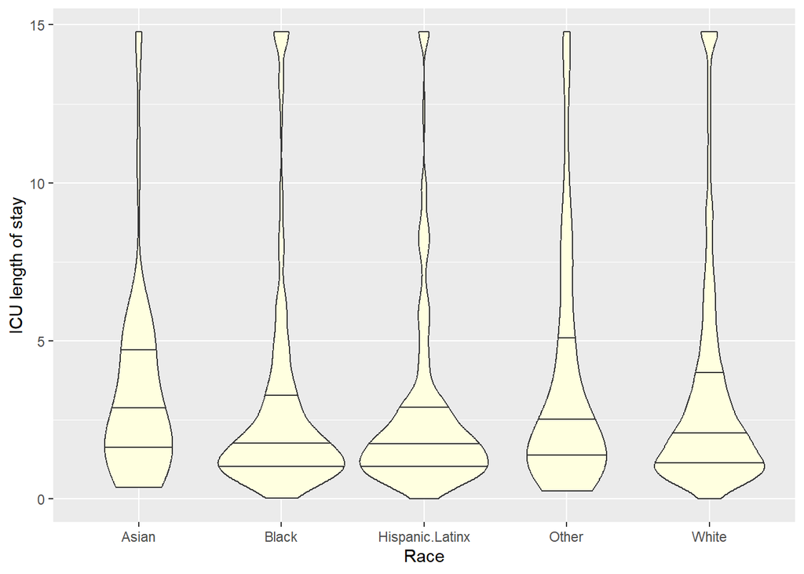

```r
print(losNrace)
```

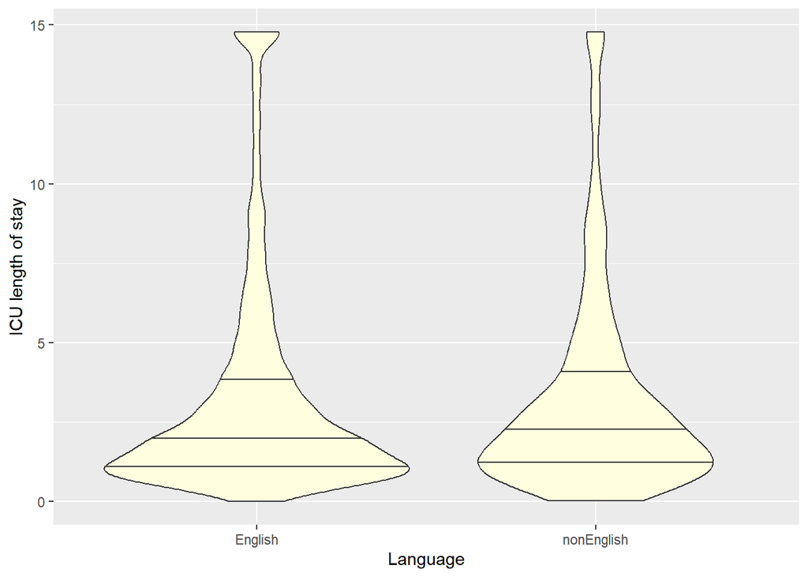

```r
print(losNlanguage)
```

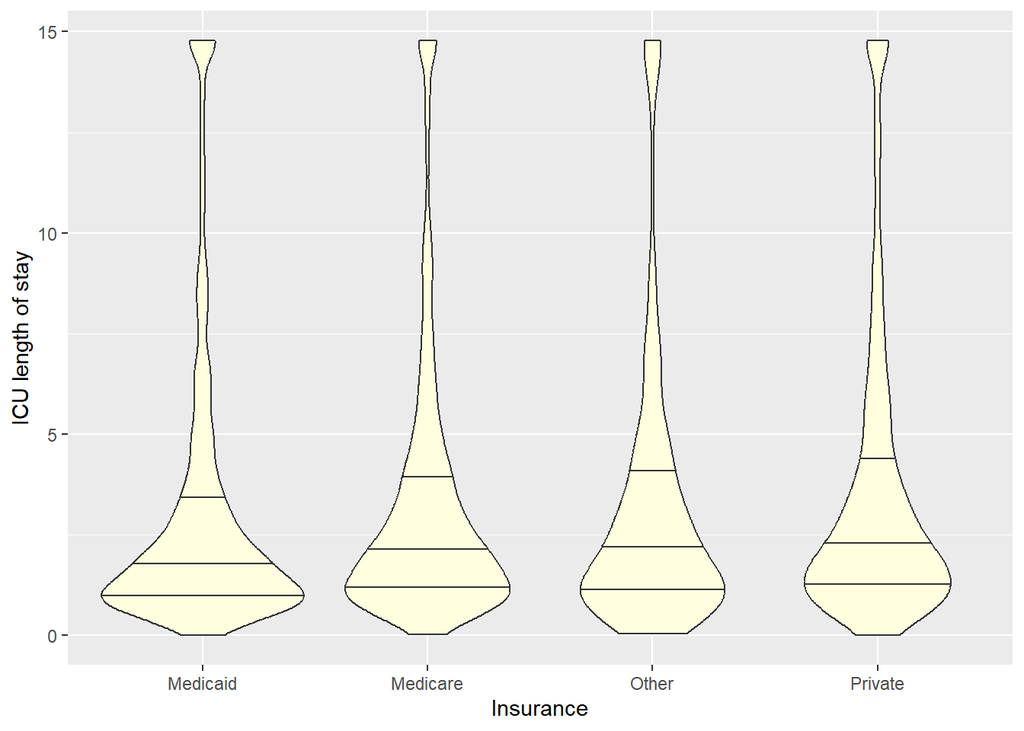

```r
print(losNinsurance)
```

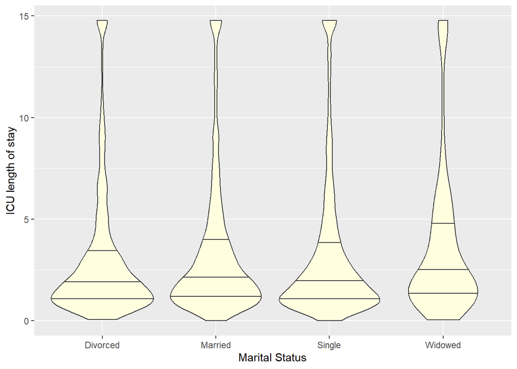

```r
print(losNmarital)
```

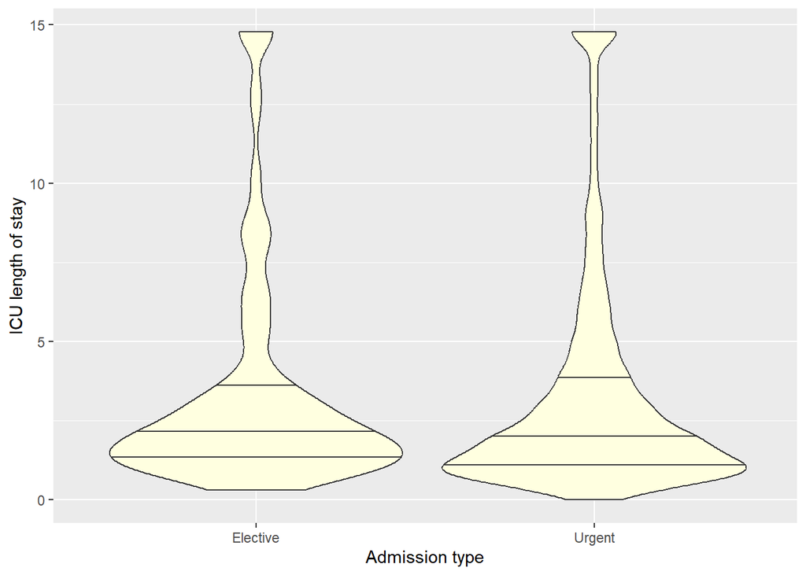

```r
print(losNadm)
```

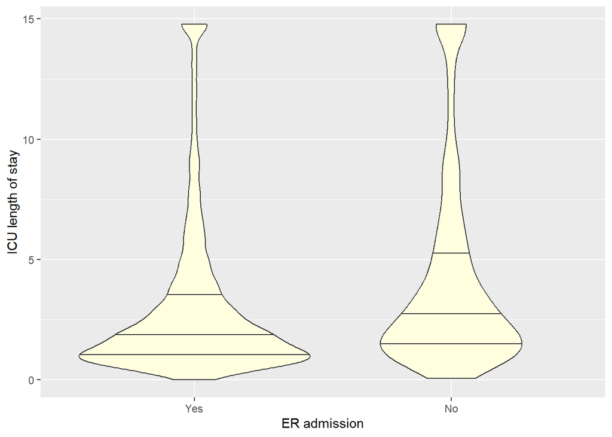

```r
print(losNEDvisit)
```

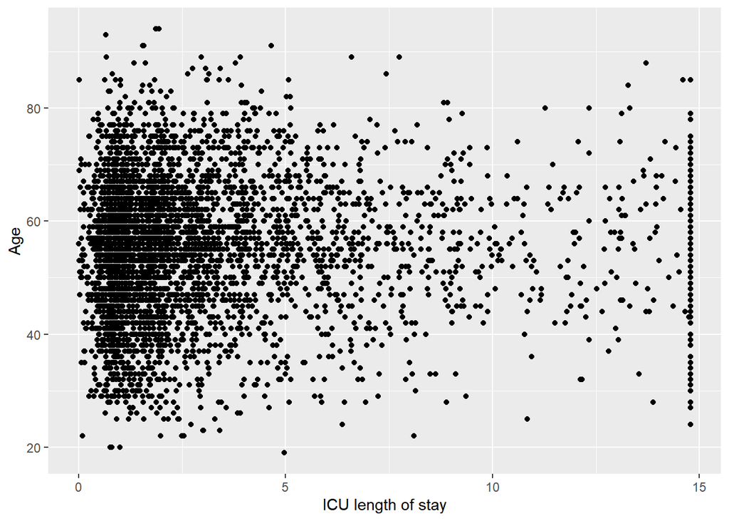

```r
print(losNage)
```

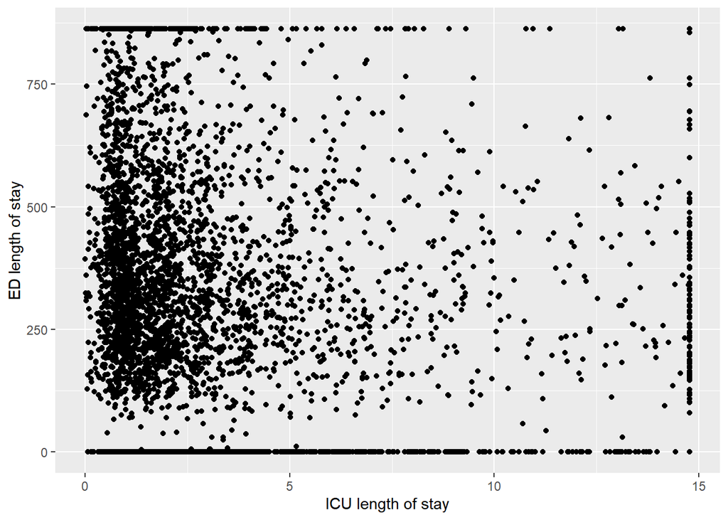

```r
print(losNEDlos)
```

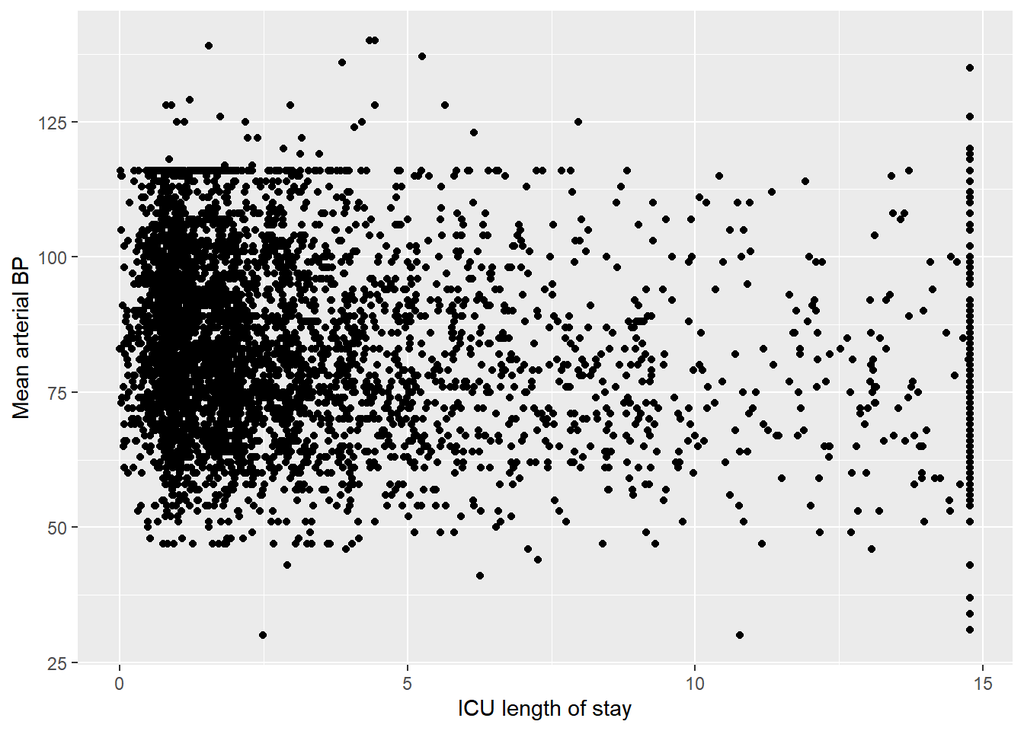

```r
print(losNmBP)
```

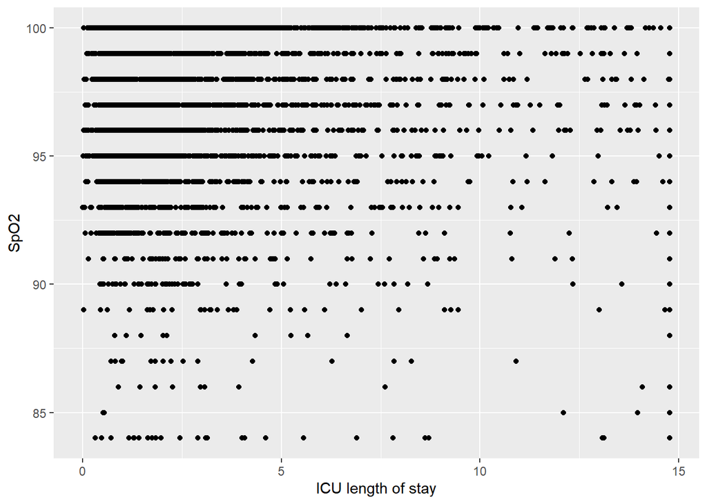

```r
print(losNSpO2)
```

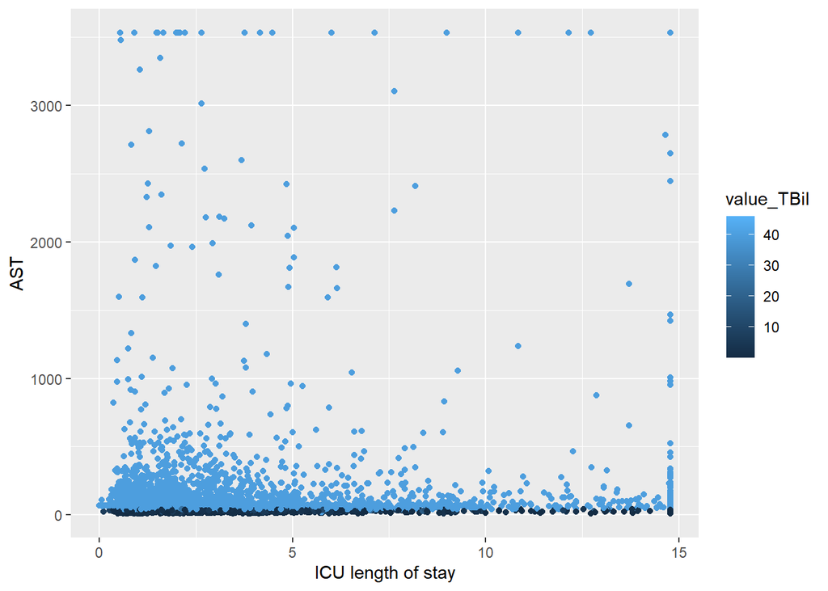

```r
print(losNast)
```

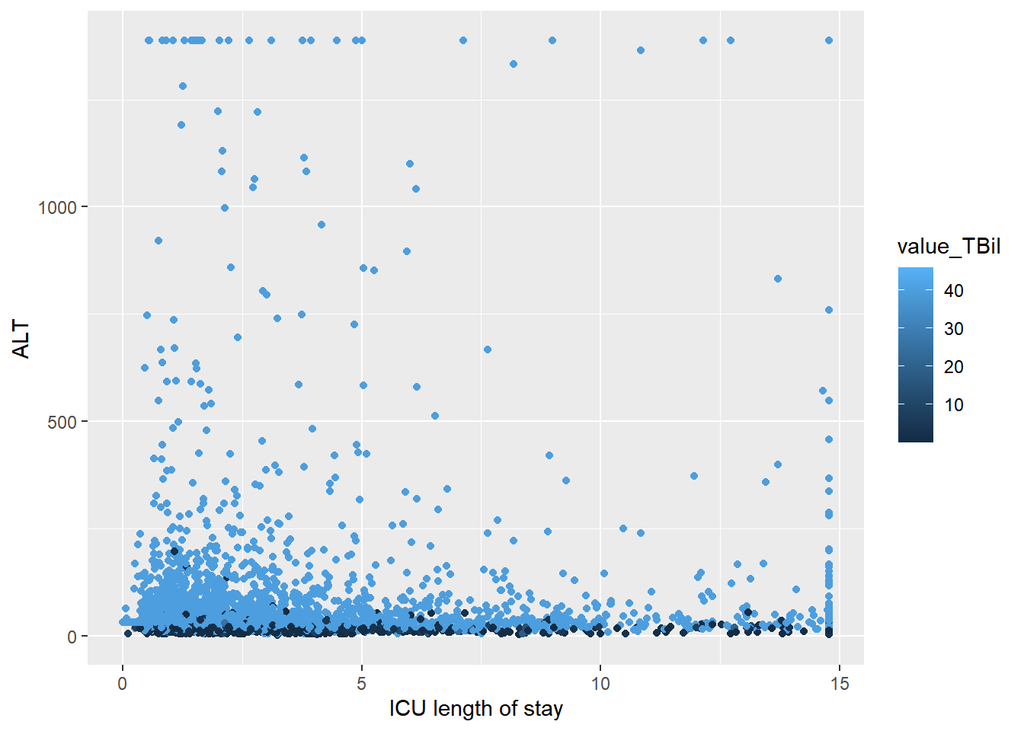

```r
print(losNalt)
```

```r
### There are no apparent relationships between each predictor variable and ICU length of stay. Hopefully, the ML model will be able to capture complex interactions and non-linear relationships that were not apparent in univariate visualizations
```

Machine learning : Logistic regression , Random Forest, and XGBoost

```r
set.seed(1234)
icu.survivor_split<-initial_split(aldNonLT_icu.survive, strata=los_icu4, prop=0.8)

icu.4days_train<- training(icu.survivor_split)
icu.4days_test<- testing(icu.survivor_split)
```

```r
#1. Logistic regression
lr_class_spec<-logistic_reg()|>
  set_engine("glm")

lr_class_fit<-lr_class_spec|>
  fit(los_icu4~age+gender+race+language+insurance+marital_status+admission_type+EDvisit+EDlos+value_RR+value_HR+value_SpO2+value_ABPm+value_Hgb+value_WBC+value_PLT+value_INR+value_PTT+value_AST+value_Cr+value_Glucose_serum+value_ALT+value_Na_serum+value_BUN+value_TBil+value_K_serum+value_HCO3_serum, data=icu.4days_train)

## 10-fold Cross-Validation
set.seed(1234)
icu.4days_folds<-vfold_cv(icu.4days_train, v=10)

glm_workflow<-workflow()|>
  add_model(lr_class_spec)|>
  add_formula(los_icu4~age+gender+race+language+insurance+marital_status+admission_type+EDvisit+EDlos+value_RR+value_HR+value_SpO2+value_ABPm+value_Hgb+value_WBC+value_PLT+value_INR+value_PTT+value_AST+value_Cr+value_Glucose_serum+value_ALT+value_Na_serum+value_BUN+value_TBil+value_K_serum+value_HCO3_serum)

glm_fit_cv<-glm_workflow|>
  fit_resamples(icu.4days_folds, control=control_resamples(save_pred=TRUE))
collect_metrics(glm_fit_cv)
```

```
# A tibble: 3 × 6
  .metric     .estimator  mean     n std_err .config
  <chr>       <chr>      <dbl> <int>   <dbl> <chr>
1 accuracy    binary     0.757    10 0.00929 Preprocessor1_Model1
2 brier_class binary     0.171    10 0.00445 Preprocessor1_Model1
3 roc_auc     binary     0.691    10 0.00773 Preprocessor1_Model1
```

```r
icu.4days_glm_cv_preds<-collect_predictions(glm_fit_cv)
icu.4days_glm_cv_preds|>
  group_by(id)|>
  roc_auc(los_icu4, `.pred_≧ 4days in ICU`)
```

```
# A tibble: 10 × 4
   id     .metric .estimator .estimate
   <chr>  <chr>   <chr>          <dbl>
 1 Fold01 roc_auc binary         0.650
 2 Fold02 roc_auc binary         0.711
 3 Fold03 roc_auc binary         0.671
 4 Fold04 roc_auc binary         0.722
 5 Fold05 roc_auc binary         0.699
 6 Fold06 roc_auc binary         0.674
 7 Fold07 roc_auc binary         0.697
 8 Fold08 roc_auc binary         0.689
 9 Fold09 roc_auc binary         0.724
10 Fold10 roc_auc binary         0.669
```

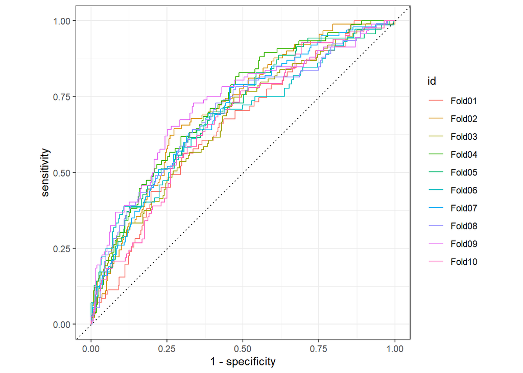

```r
icu.4days_glm_cv_preds|>
  group_by(id)|>
  roc_curve(los_icu4, `.pred_≧ 4days in ICU`)|>
  autoplot()
```

```r
## prediction on unseen testing data
icu.4days_lr_pred_test<-bind_cols(truth=icu.4days_test$los_icu4, predict(lr_class_fit, icu.4days_test), predict(lr_class_fit, icu.4days_test, type="prob"))
icu.4days_lr_pred_test
```

```
# A tibble: 848 × 4
   truth          .pred_class    `.pred_≧ 4days in ICU` `.pred_< 4days in ICU`
   <fct>          <fct>                           <dbl>                  <dbl>
 1 ≧ 4days in ICU < 4days in ICU                 0.396                   0.604
 2 ≧ 4days in ICU < 4days in ICU                 0.138                   0.862
 3 < 4days in ICU < 4days in ICU                 0.215                   0.785
 4 < 4days in ICU < 4days in ICU                 0.385                   0.615
 5 ≧ 4days in ICU < 4days in ICU                 0.397                   0.603
 6 < 4days in ICU < 4days in ICU                 0.223                   0.777
 7 < 4days in ICU < 4days in ICU                 0.0809                  0.919
 8 < 4days in ICU < 4days in ICU                 0.0869                  0.913
 9 < 4days in ICU < 4days in ICU                 0.177                   0.823
10 < 4days in ICU < 4days in ICU                 0.0822                  0.918
# ℹ 838 more rows
```

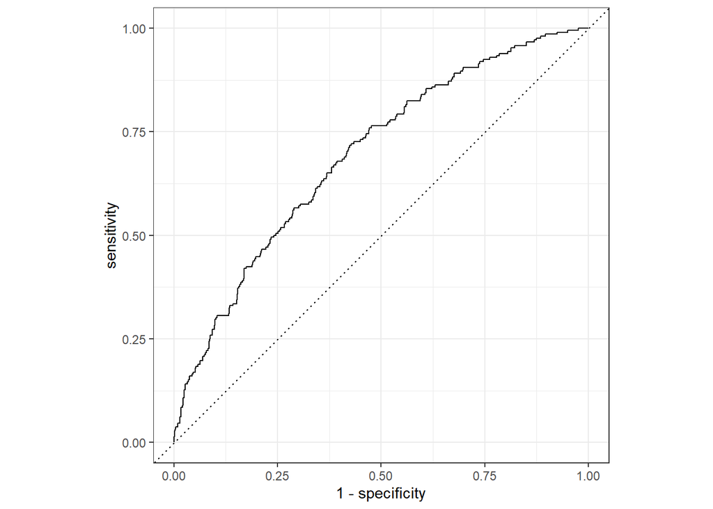

```r
autoplot(roc_curve(icu.4days_lr_pred_test, truth, `.pred_≧ 4days in ICU`))
```

```r
metrics(icu.4days_lr_pred_test, truth, .pred_class, `.pred_≧ 4days in ICU`)
```

```
# A tibble: 4 × 3
  .metric     .estimator .estimate
  <chr>       <chr>          <dbl>
1 accuracy    binary         0.759
2 kap         binary         0.157
3 mn_log_loss binary         0.518
4 roc_auc     binary         0.692
```

```r
#2. Random Forest
rf_spec<-rand_forest(trees=500, min_n=5)|>
  set_engine("randomForest", importance=TRUE)|>
  set_mode("classification")

rf_fit<-rf_spec|>
  fit(los_icu4~age+gender+race+language+insurance+marital_status+admission_type+EDvisit+EDlos+value_RR+value_HR+value_SpO2+value_ABPm+value_Hgb+value_WBC+value_PLT+value_INR+value_PTT+value_AST+value_Cr+value_Glucose_serum+value_ALT+value_Na_serum+value_BUN+value_TBil+value_K_serum+value_HCO3_serum, data=icu.4days_train)

## 10-fold Cross-Validation
set.seed(1234)
icu.4days_folds<-vfold_cv(icu.4days_train, v=10)

rf_workflow<-workflow()|>
  add_model(rf_spec)|>
  add_formula(los_icu4~age+gender+race+language+insurance+marital_status+admission_type+EDvisit+EDlos+value_RR+value_HR+value_SpO2+value_ABPm+value_Hgb+value_WBC+value_PLT+value_INR+value_PTT+value_AST+value_Cr+value_Glucose_serum+value_ALT+value_Na_serum+value_BUN+value_TBil+value_K_serum+value_HCO3_serum)

rf_fit_cv<-rf_workflow|>
  fit_resamples(icu.4days_folds, control=control_resamples(save_pred=TRUE))
collect_metrics(rf_fit_cv)
```

```
# A tibble: 3 × 6
  .metric     .estimator  mean     n std_err .config
  <chr>       <chr>      <dbl> <int>   <dbl> <chr>
1 accuracy    binary     0.762    10 0.00892 Preprocessor1_Model1
2 brier_class binary     0.165    10 0.00422 Preprocessor1_Model1
3 roc_auc     binary     0.724    10 0.0109  Preprocessor1_Model1
```

```r
icu.4days_rf_cv_preds<-collect_predictions(rf_fit_cv)
icu.4days_rf_cv_preds|>
  group_by(id)|>
  roc_auc(los_icu4, `.pred_≧ 4days in ICU`)
```

```
# A tibble: 10 × 4
   id     .metric .estimator .estimate
   <chr>  <chr>   <chr>          <dbl>
 1 Fold01 roc_auc binary         0.675
 2 Fold02 roc_auc binary         0.750
 3 Fold03 roc_auc binary         0.701
 4 Fold04 roc_auc binary         0.733
 5 Fold05 roc_auc binary         0.734
 6 Fold06 roc_auc binary         0.747
 7 Fold07 roc_auc binary         0.728
 8 Fold08 roc_auc binary         0.725
 9 Fold09 roc_auc binary         0.778
10 Fold10 roc_auc binary         0.666
```

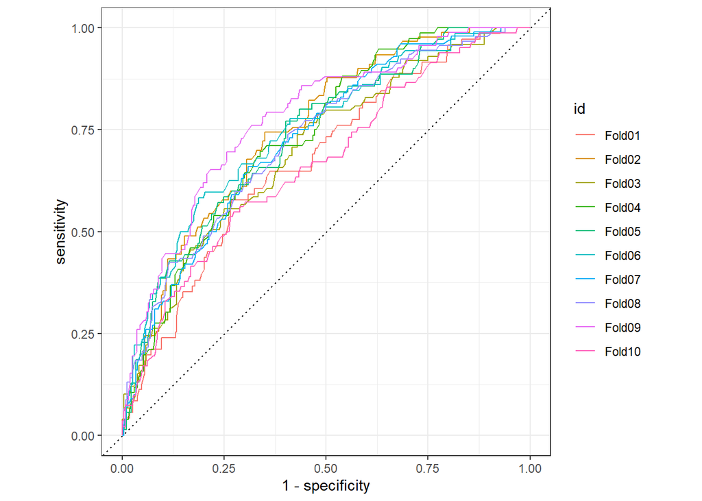

```r
icu.4days_rf_cv_preds|>
  group_by(id)|>
  roc_curve(los_icu4, `.pred_≧ 4days in ICU`)|>
  autoplot()
```

```r
## prediction on unseen testing data
icu.4days_rf_pred_test<-bind_cols(truth=icu.4days_test$los_icu4, predict(rf_fit, icu.4days_test), predict(rf_fit, icu.4days_test, type="prob"))
icu.4days_rf_pred_test
```

```
# A tibble: 848 × 4
   truth          .pred_class    `.pred_≧ 4days in ICU` `.pred_< 4days in ICU`
   <fct>          <fct>                           <dbl>                  <dbl>
 1 ≧ 4days in ICU < 4days in ICU                  0.358                  0.642
 2 ≧ 4days in ICU < 4days in ICU                  0.188                  0.812
 3 < 4days in ICU < 4days in ICU                  0.338                  0.662
 4 < 4days in ICU < 4days in ICU                  0.388                  0.612
 5 ≧ 4days in ICU < 4days in ICU                  0.46                   0.54
 6 < 4days in ICU < 4days in ICU                  0.12                   0.88
 7 < 4days in ICU < 4days in ICU                  0.032                  0.968
 8 < 4days in ICU < 4days in ICU                  0.032                  0.968
 9 < 4days in ICU < 4days in ICU                  0.1                    0.9
10 < 4days in ICU < 4days in ICU                  0.016                  0.984
# ℹ 838 more rows
```

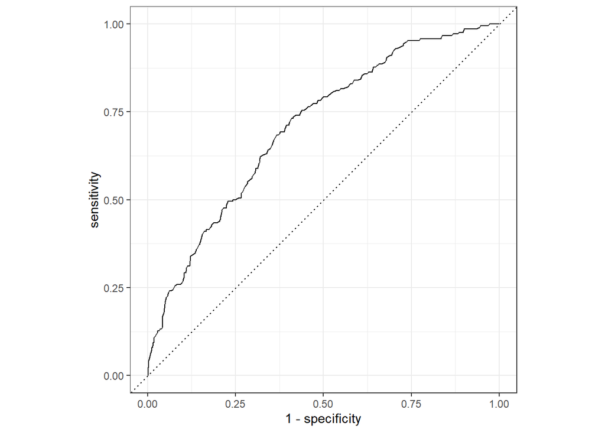

```r
autoplot(roc_curve(icu.4days_rf_pred_test, truth, `.pred_≧ 4days in ICU`))
```

```r
metrics(icu.4days_rf_pred_test, truth, .pred_class, `.pred_≧ 4days in ICU`)
```

```
# A tibble: 4 × 3
  .metric     .estimator .estimate
  <chr>       <chr>          <dbl>
1 accuracy    binary         0.761
2 kap         binary         0.112
3 mn_log_loss binary         0.511
4 roc_auc     binary         0.707
```

```r
#3. XGBoost
bt_spec<-boost_tree(trees=500, tree_depth=4)|>
  set_engine("xgboost")|>
  set_mode("classification")

bt_recipe<-recipe(los_icu4~age+gender+race+language+insurance+marital_status+admission_type+EDvisit+EDlos+value_RR+value_HR+value_SpO2+value_ABPm+value_Hgb+value_WBC+value_PLT+value_INR+value_PTT+value_AST+value_Cr+value_Glucose_serum+value_ALT+value_Na_serum+value_BUN+value_TBil+value_K_serum+value_HCO3_serum, data=icu.4days_train)|>
  step_dummy(all_nominal_predictors())|>
  step_normalize(all_predictors())

bt_workflow<-workflow()|>
  add_model(bt_spec)|>
  add_recipe(bt_recipe)

bt_fit<-fit(bt_workflow, data=icu.4days_train)

## 10-fold Cross-Validation
set.seed(1234)
icu.4days_folds<-vfold_cv(icu.4days_train, v=10)

bt_fit_cv <- bt_workflow |>
  fit_resamples(icu.4days_folds, control = control_resamples(save_pred = TRUE))
collect_metrics(bt_fit_cv)
```

```
# A tibble: 3 × 6
  .metric     .estimator  mean     n std_err .config
  <chr>       <chr>      <dbl> <int>   <dbl> <chr>
1 accuracy    binary     0.744    10 0.00674 Preprocessor1_Model1
2 brier_class binary     0.202    10 0.00455 Preprocessor1_Model1
3 roc_auc     binary     0.698    10 0.0104  Preprocessor1_Model1
```

```r
icu.4days_bt_cv_preds <- collect_predictions(bt_fit_cv)
icu.4days_bt_cv_preds |>
  group_by(id) |>
  roc_auc(los_icu4, `.pred_≧ 4days in ICU`)
```

```
# A tibble: 10 × 4
   id     .metric .estimator .estimate
   <chr>  <chr>   <chr>          <dbl>
 1 Fold01 roc_auc binary         0.650
 2 Fold02 roc_auc binary         0.717
 3 Fold03 roc_auc binary         0.737
 4 Fold04 roc_auc binary         0.694
 5 Fold05 roc_auc binary         0.712
 6 Fold06 roc_auc binary         0.722
 7 Fold07 roc_auc binary         0.720
 8 Fold08 roc_auc binary         0.666
 9 Fold09 roc_auc binary         0.719
10 Fold10 roc_auc binary         0.645
```

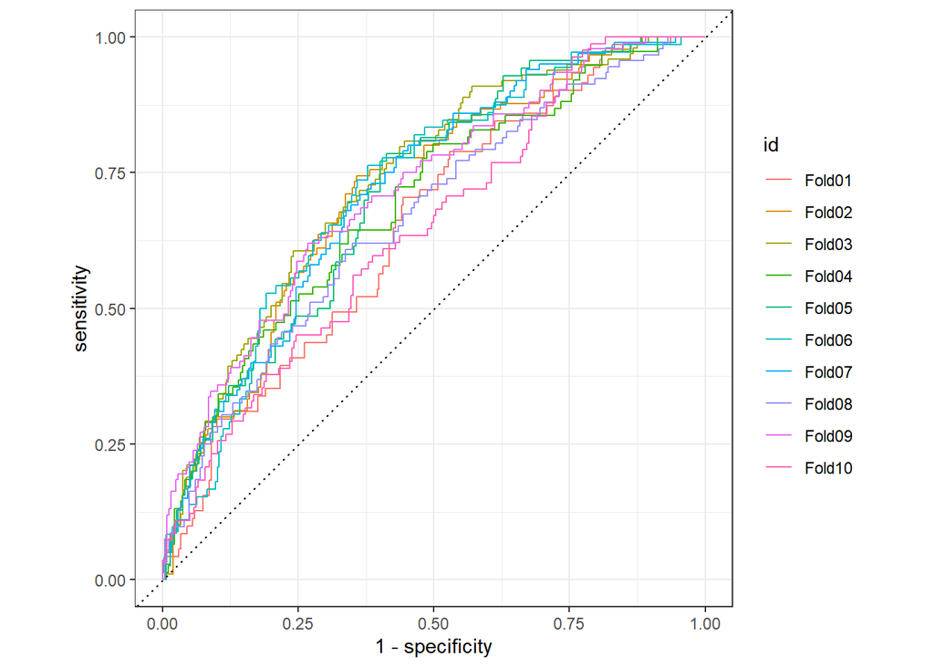

```r
icu.4days_bt_cv_preds |>
  group_by(id) |>
  roc_curve(los_icu4, `.pred_≧ 4days in ICU`) |>
  autoplot()
```

```r
## prediction on unseen testing data
icu.4days_xgb_pred_test<-bind_cols(truth = icu.4days_test$los_icu4, predict(bt_fit, icu.4days_test), predict(bt_fit, icu.4days_test, type = "prob"))
icu.4days_xgb_pred_test
```

```
# A tibble: 848 × 4
   truth          .pred_class    `.pred_≧ 4days in ICU` `.pred_< 4days in ICU`
   <fct>          <fct>                           <dbl>                  <dbl>
 1 ≧ 4days in ICU < 4days in ICU               0.0790                    0.921
 2 ≧ 4days in ICU < 4days in ICU               0.0128                    0.987
 3 < 4days in ICU < 4days in ICU               0.0114                    0.989
 4 < 4days in ICU ≧ 4days in ICU               0.550                     0.450
 5 ≧ 4days in ICU ≧ 4days in ICU               0.690                     0.310
 6 < 4days in ICU < 4days in ICU               0.000616                  0.999
 7 < 4days in ICU < 4days in ICU               0.000125                  1.00
 8 < 4days in ICU < 4days in ICU               0.000283                  1.00
 9 < 4days in ICU < 4days in ICU               0.000100                  1.00
10 < 4days in ICU < 4days in ICU               0.000124                  1.00
# ℹ 838 more rows
```

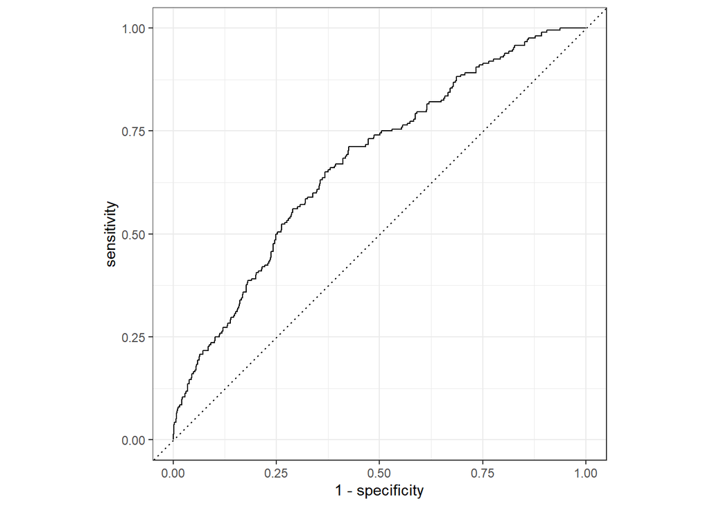

```r
autoplot(roc_curve(icu.4days_xgb_pred_test, truth, `.pred_≧ 4days in ICU`))
```

```r
metrics(icu.4days_xgb_pred_test, truth, .pred_class, `.pred_≧ 4days in ICU`)
```

```
# A tibble: 4 × 3
  .metric     .estimator .estimate
  <chr>       <chr>          <dbl>
1 accuracy    binary         0.728
2 kap         binary         0.165
3 mn_log_loss binary         0.773
4 roc_auc     binary         0.675
```

All three approaches have relatively low AUC values, and their performance tends decline on the testing data, suggesting potential overfitting issues.

Feature selection from all three models

```r
# top variables from logistic regression
library(broom)
significant_predictors <- tidy(lr_class_fit$fit) %>% filter(p.value < 0.05)
print(significant_predictors)
```

```
# A tibble: 12 × 5
   term                 estimate std.error statistic     p.value
   <chr>                   <dbl>     <dbl>     <dbl>       <dbl>
 1 (Intercept)          4.92      1.94          2.54 0.0111
 2 EDvisitNo           -0.331     0.139        -2.37 0.0176
 3 value_RR            -0.0231    0.00856      -2.70 0.00692
 4 value_HR            -0.00800   0.00240      -3.33 0.000855
 5 value_ABPm           0.0122    0.00280       4.38 0.0000121
 6 value_WBC           -0.0317    0.00626      -5.06 0.000000414
 7 value_AST           -0.000582  0.000261     -2.23 0.0256
 8 value_Cr            -0.199     0.0544       -3.66 0.000248
 9 value_Glucose_serum -0.00268   0.000932     -2.88 0.00403
10 value_Na_serum      -0.0285    0.00700      -4.07 0.0000479
11 value_TBil           0.00680   0.00267       2.55 0.0109
12 value_HCO3_serum     0.0216    0.00939       2.30 0.0216
```

```r
# top variables from random forest
rf_fit|>
  extract_fit_engine()|>
  importance()|>
  as.data.frame()|>
  arrange(desc(MeanDecreaseGini))
```

```
                    ≧ 4days in ICU < 4days in ICU MeanDecreaseAccuracy
value_WBC              12.66860147     22.1204568           25.7924114
value_PTT               7.17213259     12.3086918           14.3081824
value_Cr                6.95195890     18.6024831           20.9836169
value_ABPm              4.78635776     10.7962735           12.6219489
value_AST              -2.57767129     16.9806922           17.0931998
value_ALT               0.07774479     18.2686077           18.1308432
value_BUN              -1.19404569     15.8218726           15.1830984
value_HR                1.89601424      7.1322846            7.0757009
value_PLT              -2.36585967      7.3358574            5.2783493
value_Glucose_serum     1.49207539      3.4465904            3.8805106
value_Na_serum          4.13556221     11.4522803           12.1511945
value_Hgb               0.24347987      7.1259880            6.6448963
value_K_serum           4.63507256      1.9983741            4.0829101
value_HCO3_serum        4.71465087      9.6778533           10.6330930
EDlos                   1.06659273      7.8604370            8.0298344
age                     1.49312760      7.5839072            7.3486199
value_RR                3.14395582      4.8025864            5.7480249
value_INR              -3.46749818     14.8675231           13.4215170
value_SpO2              0.97519440      2.4167521            2.5638468
insurance              -0.76940825      4.0481358            3.0934939
marital_status          0.41378493      2.4008037            2.3738809
value_TBil             -5.16200096      9.8839885            8.6768136
race                    0.23552057      3.0011798            2.6051271
EDvisit                -2.06167651      5.3802015            4.4953799
gender                 -0.85699628      3.8319622            2.7957350
language               -0.55532943      0.1125885           -0.2019277
admission_type         -0.64025835      0.1739167           -0.1435911
                    MeanDecreaseGini
value_WBC                  89.168541
value_PTT                  66.673674
value_Cr                   64.404788
value_ABPm                 54.797241
value_AST                  54.599433
value_ALT                  54.289828
value_BUN                  53.782540
value_HR                   53.524157
value_PLT                  53.190892
value_Glucose_serum        52.771929
value_Na_serum             50.904194
value_Hgb                  49.262869
value_K_serum              44.238059
value_HCO3_serum           43.932706
EDlos                      43.745885
age                        43.634128
value_RR                   41.950777
value_INR                  39.827192
value_SpO2                 30.672074
insurance                  19.620183
marital_status             18.431082
value_TBil                 17.038639
race                       16.117863
EDvisit                     5.967841
gender                      5.427753
language                    3.004376
admission_type              2.500207
```

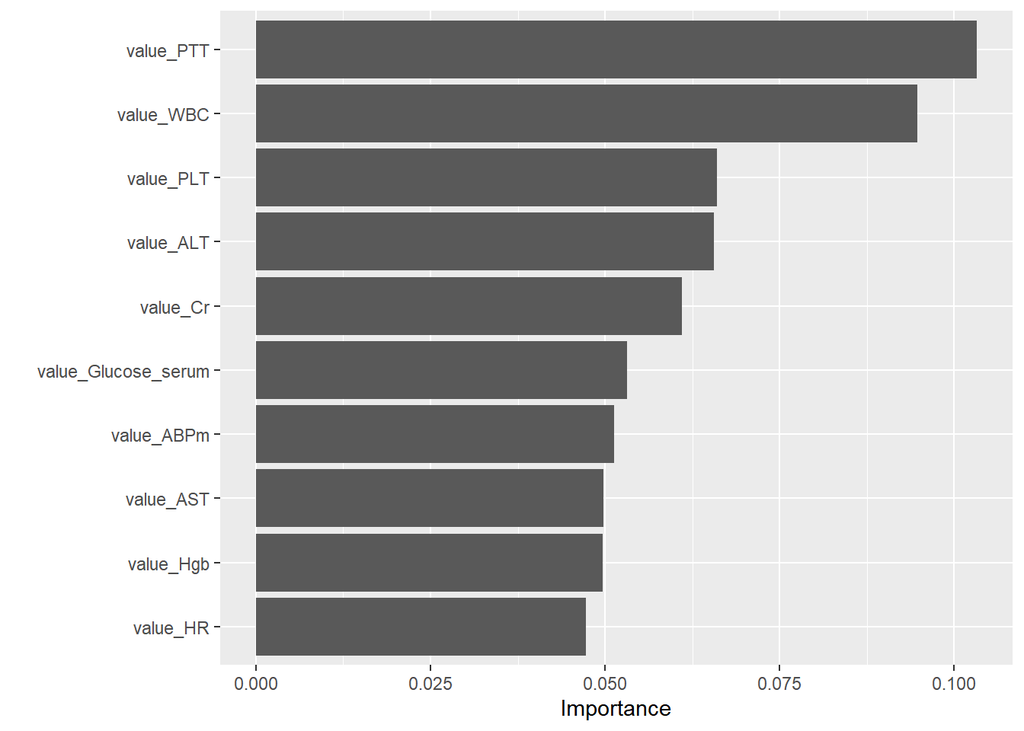

```r
# top variables from XGBoost
vip(bt_fit)
```

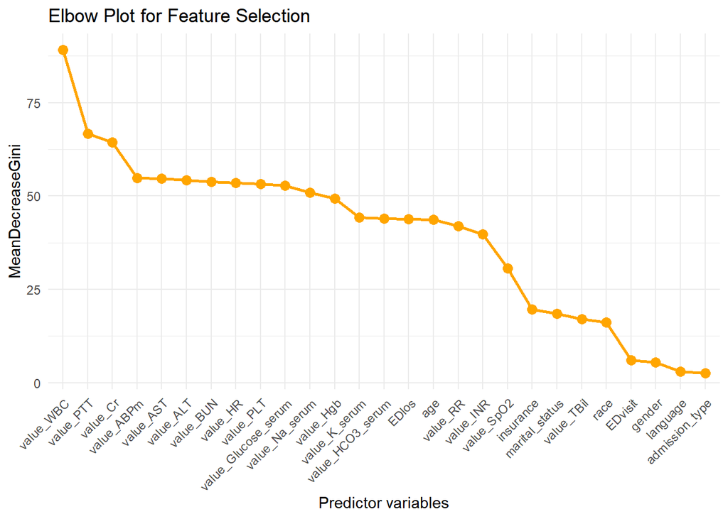

```r
# Elbow plot to determine drop threshold
rf_fit |>
  extract_fit_engine() |>
  importance() |>
  as.data.frame() |>
  rownames_to_column(var = "Predictor") |>
  arrange(desc(MeanDecreaseGini)) |>
  ggplot(aes(x = reorder(Predictor, -MeanDecreaseGini), y = MeanDecreaseGini)) +
  geom_point(color="orange", size=3) +
  geom_line(color="orange", group=1, linewidth=1) +
  theme_minimal() +
  labs(
    title = "Elbow Plot for Feature Selection",
    x = "Predictor variables",
    y = "MeanDecreaseGini"
  ) +
  theme(axis.text.x = element_text(angle = 45, hjust = 1))
```

```r
set.seed(5678)
icu.survivor_split_top<-initial_split(aldNonLT_icu.survive, strata=los_icu4, prop=0.8)

icu.4days_train_top<- training(icu.survivor_split_top)
icu.4days_test_top<- testing(icu.survivor_split_top)
```

```r
rf_spec_top<-rand_forest(trees=500, min_n=5)|>
  set_engine("randomForest", importance=TRUE)|>
  set_mode("classification")

rf_fit_top<-rf_spec_top|>
  fit(los_icu4~value_HR+value_ABPm+value_Hgb+value_WBC+value_PLT+value_PTT+value_AST+value_Cr+value_Glucose_serum+value_ALT+value_Na_serum+value_BUN, data=icu.4days_train_top)

## 10-fold Cross-Validation
set.seed(5678)
icu.4days_folds_top<-vfold_cv(icu.4days_train_top, v=10)

rf_workflow_top<-workflow()|>
  add_model(rf_spec_top)|>
  add_formula(los_icu4~value_HR+value_ABPm+value_Hgb+value_WBC+value_PLT+value_PTT+value_AST+value_Cr+value_Glucose_serum+value_ALT+value_Na_serum+value_BUN)

rf_fit_cv_top<-rf_workflow_top|>
  fit_resamples(icu.4days_folds_top, control=control_resamples(save_pred=TRUE))
collect_metrics(rf_fit_cv_top)
```

```
# A tibble: 3 × 6
  .metric     .estimator  mean     n std_err .config
  <chr>       <chr>      <dbl> <int>   <dbl> <chr>
1 accuracy    binary     0.758    10 0.00759 Preprocessor1_Model1
2 brier_class binary     0.167    10 0.00375 Preprocessor1_Model1
3 roc_auc     binary     0.716    10 0.00727 Preprocessor1_Model1
```

```r
icu.4days_rf_cv_preds_top<-collect_predictions(rf_fit_cv_top)
icu.4days_rf_cv_preds_top|>
  group_by(id)|>
  roc_auc(los_icu4, `.pred_≧ 4days in ICU`)
```

```
# A tibble: 10 × 4
   id     .metric .estimator .estimate
   <chr>  <chr>   <chr>          <dbl>
 1 Fold01 roc_auc binary         0.741
 2 Fold02 roc_auc binary         0.735
 3 Fold03 roc_auc binary         0.748
 4 Fold04 roc_auc binary         0.694
 5 Fold05 roc_auc binary         0.711
 6 Fold06 roc_auc binary         0.738
 7 Fold07 roc_auc binary         0.692
 8 Fold08 roc_auc binary         0.716
 9 Fold09 roc_auc binary         0.690
10 Fold10 roc_auc binary         0.693
```

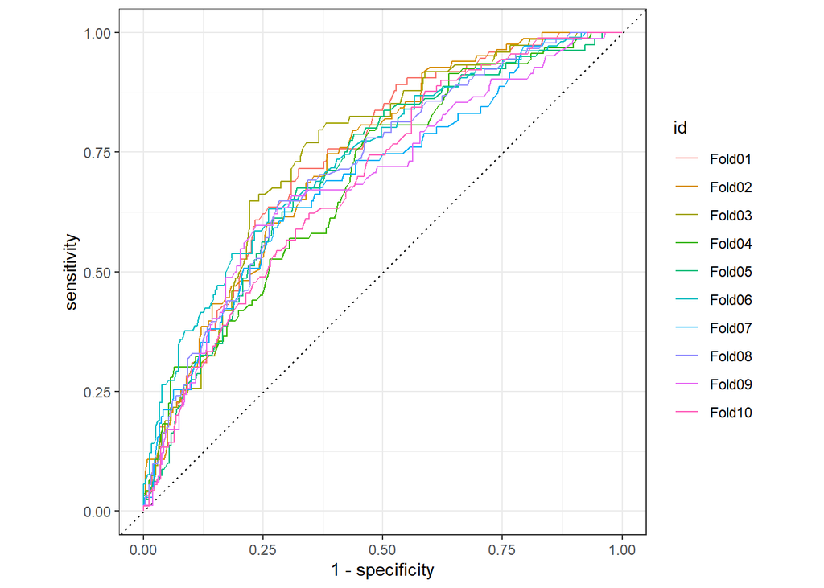

```r
icu.4days_rf_cv_preds_top|>
  group_by(id)|>
  roc_curve(los_icu4, `.pred_≧ 4days in ICU`)|>
  autoplot()
```

```r
## prediction on unseen testing data
icu.4days_rf_pred_test_top<-bind_cols(truth=icu.4days_test_top$los_icu4, predict(rf_fit_top, icu.4days_test_top), predict(rf_fit_top, icu.4days_test_top, type="prob"))
icu.4days_rf_pred_test_top
```

```
# A tibble: 848 × 4
   truth          .pred_class    `.pred_≧ 4days in ICU` `.pred_< 4days in ICU`
   <fct>          <fct>                           <dbl>                  <dbl>
 1 < 4days in ICU < 4days in ICU                  0.25                   0.75
 2 ≧ 4days in ICU < 4days in ICU                  0.428                  0.572
 3 ≧ 4days in ICU < 4days in ICU                  0.204                  0.796
 4 < 4days in ICU < 4days in ICU                  0.43                   0.57
 5 < 4days in ICU < 4days in ICU                  0.414                  0.586
 6 ≧ 4days in ICU < 4days in ICU                  0.4                    0.6
 7 < 4days in ICU < 4days in ICU                  0.33                   0.67
 8 < 4days in ICU < 4days in ICU                  0.458                  0.542
 9 < 4days in ICU < 4days in ICU                  0.118                  0.882
10 < 4days in ICU < 4days in ICU                  0                      1
# ℹ 838 more rows
```

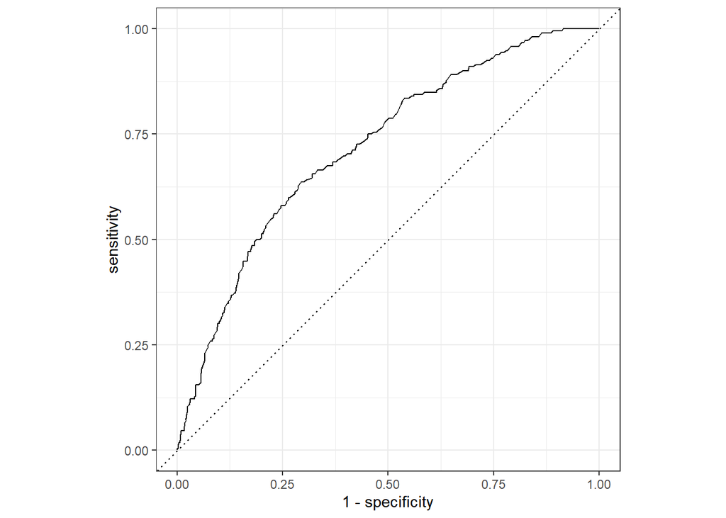

```r
autoplot(roc_curve(icu.4days_rf_pred_test_top, truth, `.pred_≧ 4days in ICU`))
```

```r
metrics(icu.4days_rf_pred_test_top, truth, .pred_class, `.pred_≧ 4days in ICU`)
```

```
# A tibble: 4 × 3
  .metric     .estimator .estimate
  <chr>       <chr>          <dbl>
1 accuracy    binary         0.751
2 kap         binary         0.137
3 mn_log_loss binary         0.504
4 roc_auc     binary         0.719
```

Seems to have slightly resolved the problem of overfitting. The AUC value is still suboptimal. It could be because it’s missing a key predictor, but also curious to see if addressing multicolinearity can improve model’s performance.

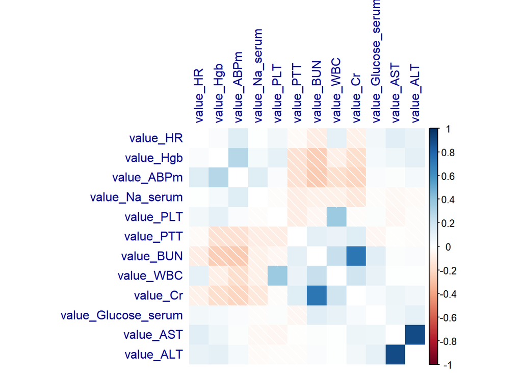

```r
# corplot to detect hidden patterns among variables
## Curious regarding why the predictors are unable to predict the outcome... could be because it is missing a key predictor, but could also be due to multicolinearity

library(corrplot)
top.predictors<-aldNonLT_icu.survive[, c("value_HR","value_ABPm","value_Hgb","value_WBC","value_PLT","value_PTT","value_AST","value_Cr","value_Glucose_serum","value_ALT","value_Na_serum","value_BUN")]
corr_matrix <- cor(top.predictors)
corrplot(corr_matrix, method = 'shade', order = 'AOE', diag = FALSE, tl.col="darkblue")
```

```r
# Would model performance improve if I remove predictors with multicolinearity? (ALT and BUN)
set.seed(0123)
icu.survivor_split_last<-initial_split(aldNonLT_icu.survive, strata=los_icu4, prop=0.8)

icu.4days_train_last<- training(icu.survivor_split_last)
icu.4days_test_last<- testing(icu.survivor_split_last)

rf_spec_last<-rand_forest(trees=500, min_n=5)|>
  set_engine("randomForest", importance=TRUE)|>
  set_mode("classification")

rf_fit_last<-rf_spec_last|>
  fit(los_icu4~value_HR+value_ABPm+value_Hgb+value_WBC+value_PLT+value_PTT+value_AST+value_Cr+value_Glucose_serum+value_Na_serum, data=icu.4days_train_last)

## 10-fold Cross-Validation
set.seed(0123)
icu.4days_folds_last<-vfold_cv(icu.4days_train_last, v=10)

rf_workflow_last<-workflow()|>
  add_model(rf_spec_last)|>
  add_formula(los_icu4~value_HR+value_ABPm+value_Hgb+value_WBC+value_PLT+value_PTT+value_AST+value_Cr+value_Glucose_serum+value_Na_serum)

rf_fit_cv_last<-rf_workflow_last|>
  fit_resamples(icu.4days_folds_last, control=control_resamples(save_pred=TRUE))
collect_metrics(rf_fit_cv_last)
```

```
# A tibble: 3 × 6
  .metric     .estimator  mean     n std_err .config
  <chr>       <chr>      <dbl> <int>   <dbl> <chr>
1 accuracy    binary     0.758    10 0.00710 Preprocessor1_Model1
2 brier_class binary     0.168    10 0.00342 Preprocessor1_Model1
3 roc_auc     binary     0.712    10 0.00946 Preprocessor1_Model1
```

```r
icu.4days_rf_cv_preds_last<-collect_predictions(rf_fit_cv_last)
icu.4days_rf_cv_preds_last|>
  group_by(id)|>
  roc_auc(los_icu4, `.pred_≧ 4days in ICU`)
```

```
# A tibble: 10 × 4
   id     .metric .estimator .estimate
   <chr>  <chr>   <chr>          <dbl>
 1 Fold01 roc_auc binary         0.735
 2 Fold02 roc_auc binary         0.740
 3 Fold03 roc_auc binary         0.763
 4 Fold04 roc_auc binary         0.681
 5 Fold05 roc_auc binary         0.695
 6 Fold06 roc_auc binary         0.674
 7 Fold07 roc_auc binary         0.721
 8 Fold08 roc_auc binary         0.728
 9 Fold09 roc_auc binary         0.679
10 Fold10 roc_auc binary         0.703
```

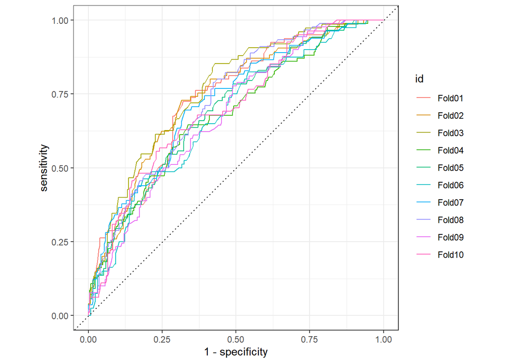

```r
icu.4days_rf_cv_preds_last|>
  group_by(id)|>
  roc_curve(los_icu4, `.pred_≧ 4days in ICU`)|>
  autoplot()
```

```r
## prediction on unseen testing data
icu.4days_rf_pred_test_last<-bind_cols(truth=icu.4days_test_last$los_icu4, predict(rf_fit_last, icu.4days_test_last), predict(rf_fit_last, icu.4days_test_last, type="prob"))
icu.4days_rf_pred_test_last
```

```
# A tibble: 848 × 4
   truth          .pred_class    `.pred_≧ 4days in ICU` `.pred_< 4days in ICU`
   <fct>          <fct>                           <dbl>                  <dbl>
 1 < 4days in ICU < 4days in ICU                  0.278                  0.722
 2 < 4days in ICU < 4days in ICU                  0.298                  0.702
 3 < 4days in ICU ≧ 4days in ICU                  0.676                  0.324
 4 < 4days in ICU < 4days in ICU                  0.282                  0.718
 5 ≧ 4days in ICU < 4days in ICU                  0.344                  0.656
 6 < 4days in ICU < 4days in ICU                  0.35                   0.65
 7 ≧ 4days in ICU < 4days in ICU                  0.23                   0.77
 8 ≧ 4days in ICU < 4days in ICU                  0.338                  0.662
 9 < 4days in ICU < 4days in ICU                  0.216                  0.784
10 < 4days in ICU < 4days in ICU                  0.032                  0.968
# ℹ 838 more rows
```

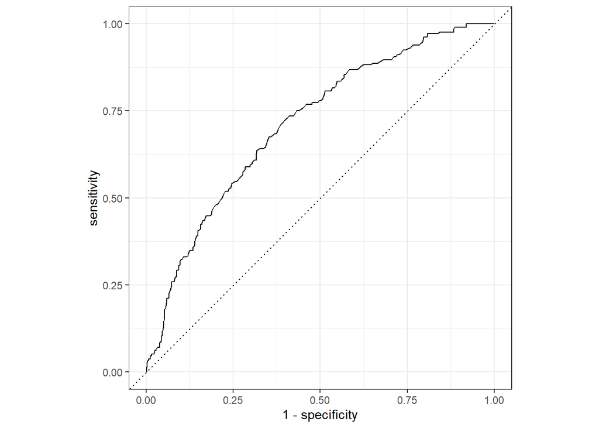

```r
autoplot(roc_curve(icu.4days_rf_pred_test_last, truth, `.pred_≧ 4days in ICU`))
```

```r
metrics(icu.4days_rf_pred_test_last, truth, .pred_class, `.pred_≧ 4days in ICU`)
```

```
# A tibble: 4 × 3
  .metric     .estimator .estimate
  <chr>       <chr>          <dbl>
1 accuracy    binary         0.752
2 kap         binary         0.150
3 mn_log_loss binary         0.509
4 roc_auc     binary         0.713
```

## 4 Results

1. **Demographics**

The mean age of individuals included in the analyzed data set was 55.1 (SD=12.1), who were mostly male, White, and English-speaking.

```r
table1(~ age + gender + race + language + insurance + marital_status + admission_type + EDvisit | los_icu4,
       data = aldNonLT_icu.survive, rowlabelhead="Demographics")
```

| Demographics | ≧ 4days in ICU (N=1056) | < 4days in ICU (N=3179) | Overall (N=4235) |
| --- | --- | --- | --- |
| Age (years) |  |  |  |
| Mean (SD) | 55.5 (12.2) | 55.0 (12.1) | 55.1 (12.1) |
| Median [Min, Max] | 56.0 [19.0, 91.0] | 56.0 [20.0, 94.0] | 56.0 [19.0, 94.0] |
| Gender |  |  |  |
| Female | 325 (30.8%) | 887 (27.9%) | 1212 (28.6%) |
| Male | 731 (69.2%) | 2292 (72.1%) | 3023 (71.4%) |
| Race |  |  |  |
| Asian | 13 (1.2%) | 29 (0.9%) | 42 (1.0%) |
| Black | 89 (8.4%) | 351 (11.0%) | 440 (10.4%) |
| Hispanic.Latinx | 50 (4.7%) | 239 (7.5%) | 289 (6.8%) |
| Other | 46 (4.4%) | 108 (3.4%) | 154 (3.6%) |
| White | 858 (81.3%) | 2452 (77.1%) | 3310 (78.2%) |
| Language |  |  |  |
| English | 991 (93.8%) | 2988 (94.0%) | 3979 (94.0%) |
| nonEnglish | 65 (6.2%) | 191 (6.0%) | 256 (6.0%) |
| Insurance |  |  |  |
| Medicaid | 342 (32.4%) | 1192 (37.5%) | 1534 (36.2%) |
| Medicare | 335 (31.7%) | 1004 (31.6%) | 1339 (31.6%) |
| Other | 51 (4.8%) | 151 (4.8%) | 202 (4.8%) |
| Private | 328 (31.1%) | 832 (26.2%) | 1160 (27.4%) |
| Marital Status |  |  |  |
| Divorced | 108 (10.2%) | 404 (12.7%) | 512 (12.1%) |
| Married | 358 (33.9%) | 1056 (33.2%) | 1414 (33.4%) |
| Single | 536 (50.8%) | 1602 (50.4%) | 2138 (50.5%) |
| Widowed | 54 (5.1%) | 117 (3.7%) | 171 (4.0%) |
| Admission Type |  |  |  |
| Elective | 34 (3.2%) | 114 (3.6%) | 148 (3.5%) |
| Urgent | 1022 (96.8%) | 3065 (96.4%) | 4087 (96.5%) |
| ED Visit |  |  |  |
| Yes | 731 (69.2%) | 2568 (80.8%) | 3299 (77.9%) |
| No | 325 (30.8%) | 611 (19.2%) | 936 (22.1%) |

2. **Univariate visualizations**

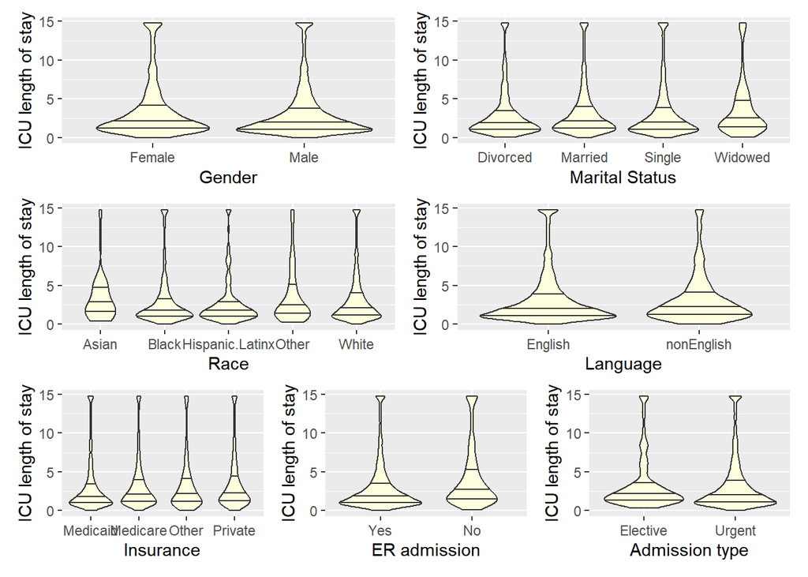

```r
library(patchwork)
violin_categ <- (losNgender | losNmarital ) /
                 (losNrace | losNlanguage ) /
                 (losNinsurance | losNEDvisit | losNadm)

print(violin_categ)
```

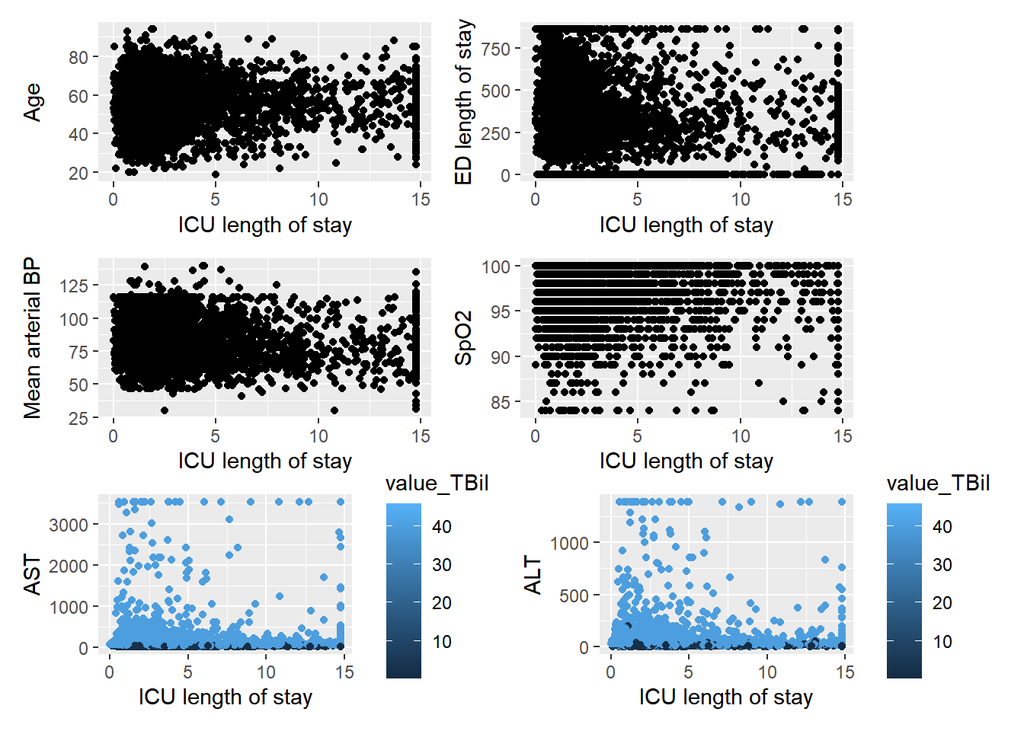

```r
scatter_cont <- (losNage | losNEDlos ) /
                 (losNmBP | losNSpO2 ) /
                 (losNast | losNalt)

print(scatter_cont)
```

3. **Comparing the three machine learning approaches**

The Random Forest approach had the best performance for predicting whether a patient’s ICU stay would last 4 days or more in the testing data set, but its AUC value is just above 0.7, which is moderate.

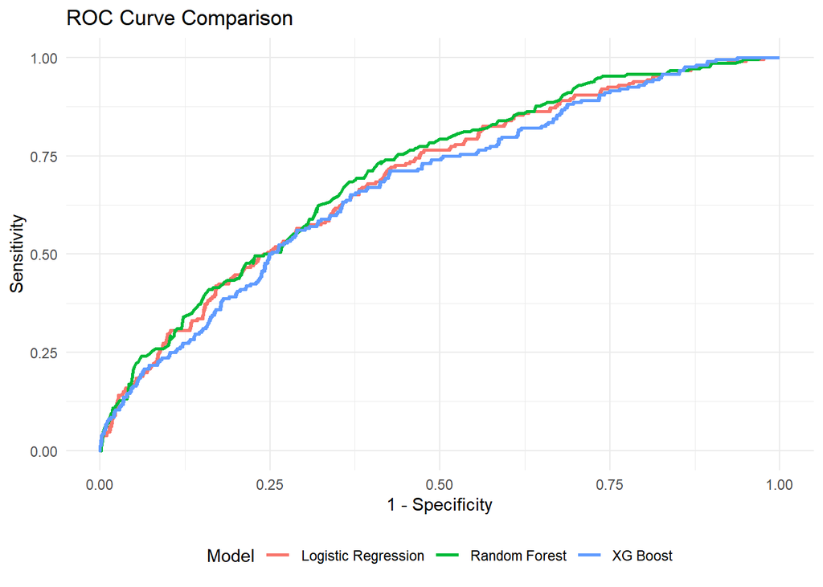

```r
lr_test_roc<-roc_curve(icu.4days_lr_pred_test, truth, `.pred_≧ 4days in ICU`)|>
  mutate(Model="Logistic Regression")
rf_test_roc<-roc_curve(icu.4days_rf_pred_test, truth, `.pred_≧ 4days in ICU`)|>
  mutate(Model="Random Forest")
xg_test_roc<-roc_curve(icu.4days_xgb_pred_test, truth, `.pred_≧ 4days in ICU`)|>
  mutate(Model="XG Boost")

all_roc<-bind_rows(lr_test_roc, rf_test_roc, xg_test_roc)

ggplot(all_roc, aes(x = 1 - specificity, y = sensitivity, color = Model)) +
  geom_line(size = 1) +
  labs(title = "ROC Curve Comparison",
       x = "1 - Specificity",
       y = "Sensitivity") +
  theme_minimal() +
  theme(legend.position = "bottom")
```

4. **Model optimization effects**

Although it didn’t significantly improve the Random Forest model’s predictive performance, model optimization by using top predictors seemed to reduce overfitting and improved interpretability of the model.

```r
bind_rows(
    icu.4days_rf_cv_preds |>
    summarise(Model = "Random Forest (All Features, CV)",
              ROC_AUC = roc_auc_vec(truth = los_icu4, estimate = `.pred_≧ 4days in ICU`)),
  icu.4days_rf_pred_test |>
    summarise(Model = "Random Forest (All Features, Test)",
              ROC_AUC = roc_auc_vec(truth = truth, estimate = `.pred_≧ 4days in ICU`)),
  icu.4days_rf_cv_preds_top |>
    summarise(Model = "Random Forest (Top Features, CV)",
              ROC_AUC = roc_auc_vec(truth = los_icu4, estimate = `.pred_≧ 4days in ICU`)),
  icu.4days_rf_pred_test_top |>
    summarise(Model = "Random Forest (Top Features, Test)",
              ROC_AUC = roc_auc_vec(truth = truth, estimate = `.pred_≧ 4days in ICU`)),
)
```

```
# A tibble: 4 × 2
  Model                              ROC_AUC
  <chr>                                <dbl>
1 Random Forest (All Features, CV)     0.724
2 Random Forest (All Features, Test)   0.707
3 Random Forest (Top Features, CV)     0.715
4 Random Forest (Top Features, Test)   0.719
```

5. **Future steps: transforming predictor variables based on corrplot results and peer feedback**

To further enhance the model’s interpretation, I will consider transforming the highly correlated predictor variables (BUN and ALT) into a BUN/Cr ratio and AST/ALT ratio, and perhaps calculate the MELD score (Model for End-Stage Liver Disease score; based on INR, Cr, Bilirubin, Na levels) to include as a predictor instead of using individual lab values. Capping vital signs and lab values may not accurately reflect the acute condition of ALD patients, so I plan to meet with my advisors to discuss more regarding the management of extreme outliers. I also aim to incorporate comorbidities and medication histories to improve model performance.

## 5 Conclusion

The Random Forest model demonstrated the highest predictive accuracy for classifying whether an ALD patient’s ICU stay would last 4 days or more, compared to logistic regression and XGBoost models. However, its performance was moderate, with an AUC of just over 70%. This highlights room for improvement and provides a basis for future optimization efforts. After a satisfactory AUC value is obtained for the model, it would still require caution and external validation before its implementaton in practice, especially given the demographic homogeneity of the patients that were used to train and test this model. Once the final model is validated, it will support proactive planning for patient care, caregiver schedules, and resource allocation by indicating the patient’s projected recovery or decline.